# Thesis Chapter 4 Analysis

Chapter 4 abstract: I was interested in how Psychrobacter isolated from different ecological niches might exhibit differences in phenotypic behavior, so I performed a large scale phenotype collection on 85 Psychrobacter strains. I collected information on strains’ oxygen utilization profiles and abilities (or lack thereof) to grow in 24 different conditions, along with growth rate and maximum optical density reached. I found that Psychrobacter isolation source is strongly correlated with ability/inability to grow under certain conditions, with strains isolated from mammals and birds more likely to grow in rich media, low salt, and high temperature conditions compared to strains from other isolation sources. Isolation source and isolation location are also very weakly correlated with growth rate and maximum optical density, but explain very little of the variation in the data. Strains from birds and mammals are less likely to be strict aerobes than strains from other isolation sources, but not significantly. Overall, my data shows that Psychrobacter strains isolated from warm-bodied hosts behave somewhat differently than Psychrobacter strains from other isolation sources, and in particular, this difference is likely driven by more phylogenetically basal strains.

[output not shown]

# Growth curve data processing

I'll analyze GrowthBin separately from growth rate (r) and max OD (k), since I *have* growth bin data for all conditions, whereas some conditions could not be modeled and the r and k data is therefore missing.

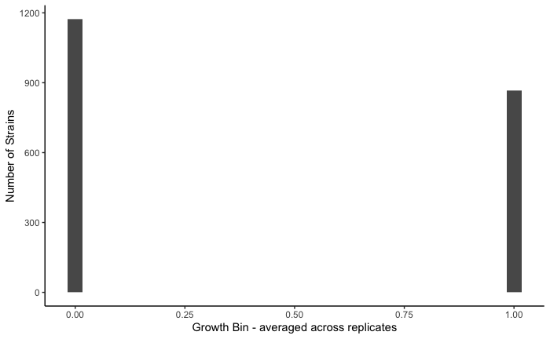

```r
psychgb = psych_growthbin
psychgb$gc = str_c(psychgb$medium, psychgb$salt, psychgb$temperature, sep = '_')
psychgb_agg = aggregate(psychgb$GrowthBin, by = list(psychgb$propername, psychgb$gc), FUN = mean)
colnames(psychgb_agg) = c("strainID", "GC", "growthbin_ag")
psychgb_agg$growthbin_ag[psychgb_agg$growthbin_ag < 0.5] <- 0
psychgb_agg$growthbin_ag[psychgb_agg$growthbin_ag >= 0.5] <- 1
psychgb_agg = psychgb_agg %>% spread(GC, growthbin_ag)
psych_gb_distrib = melt(psychgb_agg)
(gbdistrib = ggplot(data = psych_gb_distrib, aes(x = value)) + geom_histogram() +
  theme_classic() + xlab("Growth Bin - averaged across replicates") + ylab("Number of Strains"))
```

```r
#set.seed(0)
#pc <- prcomp(psychgb_agg %>% select(-strainID), scale. = TRUE, retx = TRUE)
```

### Figure 4.2

```r
#NMDS for growth bin
gb_for_nmds = psychgb_agg[,2:25]
rownames(gb_for_nmds) = psychgb_agg$strainID
gb_for_nmds = t(gb_for_nmds)
set.seed(0)
gb_nmds_2dim = metaMDS(gb_for_nmds, k = 2, trymax = 100, autotransform = FALSE)
```

```
*** Solution reached
```

```r
gb_nmds_2dim
```

```
Call:
metaMDS(comm = gb_for_nmds, k = 2, trymax = 100, autotransform = FALSE)

global Multidimensional Scaling using monoMDS

Data:     gb_for_nmds
Distance: bray

Dimensions: 2
Stress:     0.09251779
Stress type 1, weak ties
Two convergent solutions found after 25 tries
Scaling: centring, PC rotation, halfchange scaling
Species: expanded scores based on ‘gb_for_nmds’
```

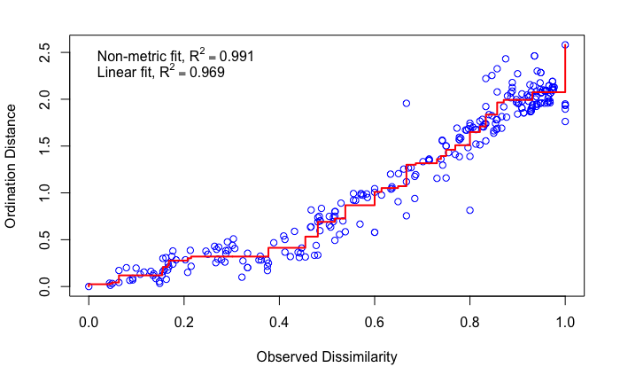

```r
stressplot(gb_nmds_2dim)
```

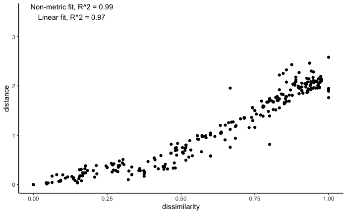

```r
gb_stress = as.data.frame(cbind(gb_nmds_2dim$diss, gb_nmds_2dim$dist))
colnames(gb_stress) = c("dissimilarity", "distance")
(nmds_stress_gb = ggplot(data = gb_stress, aes(x = dissimilarity, y = distance)) +
    geom_point() +
    annotate(geom = "text", x = 0.13, y = 3.5, label = str_c('Non-metric fit, R^2 = 0.99\nLinear fit, R^2 = 0.97')) +
    theme_classic())
```

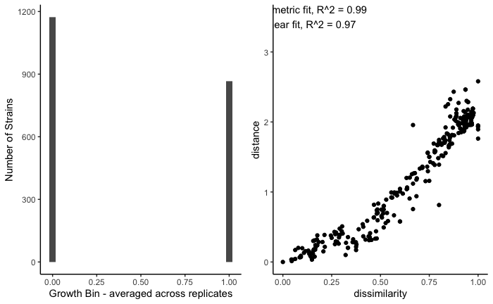

```r
ggarrange(gbdistrib, nmds_stress_gb)
```

### Figure 4.3

```r
psychkr = psych_growthcurves %>% select(-strain_plus_code,-GrowthBin)
psychkr$r[psychkr$r == 0] <- NA
psychkr$gc = str_c(psychkr$medium, psychkr$salt, psychkr$temperature, sep = '_')
psychkr_agg = suppressWarnings(aggregate(psychkr, by = list(psychkr$strainID, psychkr$gc), FUN = mean))
psychkr_agg = psychkr_agg[,c(1,2,8:12)]
colnames(psychkr_agg)[1:2] = c("strainID", "GC")
psychkr_agg_k = psychkr_agg %>% select(strainID, GC, k) %>% spread(GC, k)
colnames(psychkr_agg_k)[2:25] <- paste(colnames(psychkr_agg_k)[2:25], "k", sep = "_")
psychkr_agg_r = psychkr_agg %>% select(strainID, GC, r) %>% spread(GC, r)
colnames(psychkr_agg_r)[2:25] <- paste(colnames(psychkr_agg_r)[2:25], "r", sep = "_")
psych_kr_kr = left_join(psychkr_agg_k, psychkr_agg_r)
library(randomForest)
psych_kr_kr = na.roughfix(psych_kr_kr[,2:49])
rownames(psych_kr_kr) = psychkr_agg_k$strainID
psych_kr_kr <- psych_kr_kr %>%
  filter_all(any_vars(. != 0))
setdiff(psychkr_agg_k$strainID, rownames(psych_kr_kr))
```

```
character(0)
```

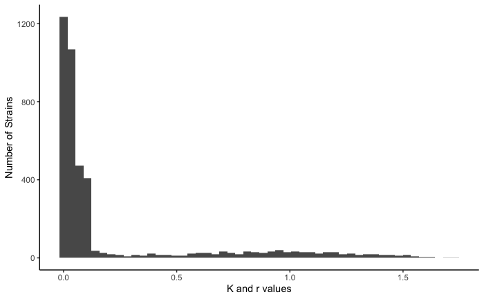

```r
psych_kr_distrib = melt(psych_kr_kr)
(krdistrib = ggplot(data = psych_kr_distrib, aes(x = value)) + geom_histogram(bins = 50) +
  theme_classic() + xlab("K and r values") + ylab("Number of Strains"))
```

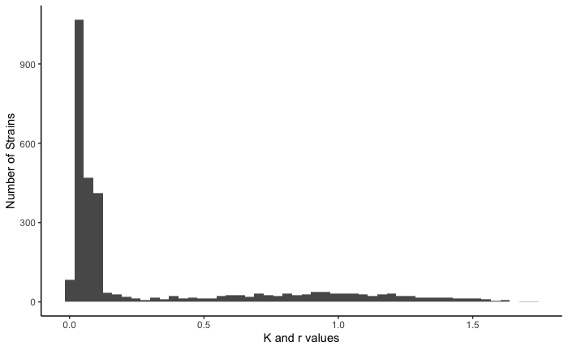

```r
psych_kr_distrib_nozero = psych_kr_distrib %>% filter(value != 0)
ggplot(data = psych_kr_distrib_nozero, aes(x = value)) + geom_histogram(bins = 50) +
  theme_classic() + xlab("K and r values") + ylab("Number of Strains")
```

```r
psych_kr_kr_t = t(psych_kr_kr)
psych_kr_kr_t_scale = apply(psych_kr_kr_t, MARGIN = 2, FUN = function(X) (X - min(X))/diff(range(X)))
set.seed(0)
kr_nmds_2dim = metaMDS(psych_kr_kr_t_scale, k = 2, trymax = 100, autotransform = FALSE)
```

```
*** Solution reached
```

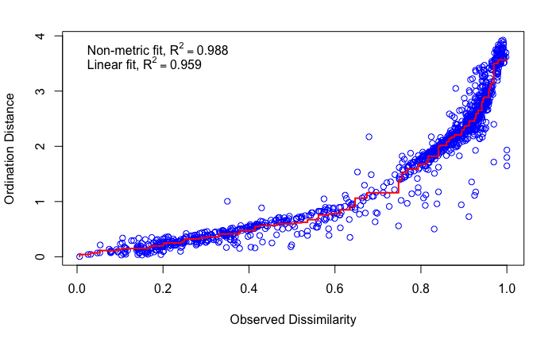

```r
stressplot(kr_nmds_2dim)
```

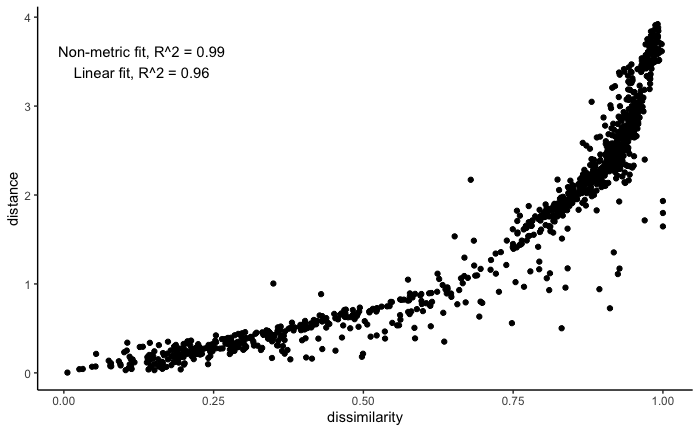

```r
kr_stress = as.data.frame(cbind(kr_nmds_2dim$diss, kr_nmds_2dim$dist))
colnames(kr_stress) = c("dissimilarity", "distance")
(nmds_stress = ggplot(data = kr_stress, aes(x = dissimilarity, y = distance)) +
    geom_point() +
    annotate(geom = "text", x = 0.13, y = 3.5, label = str_c('Non-metric fit, R^2 = 0.99\nLinear fit, R^2 = 0.96')) +
    theme_classic())
```

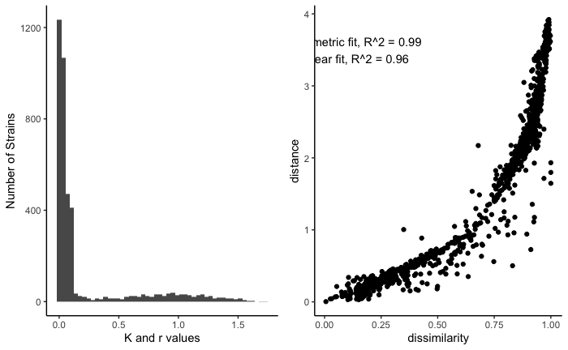

```r
ggarrange(krdistrib, nmds_stress)
```

### Figure 4.5

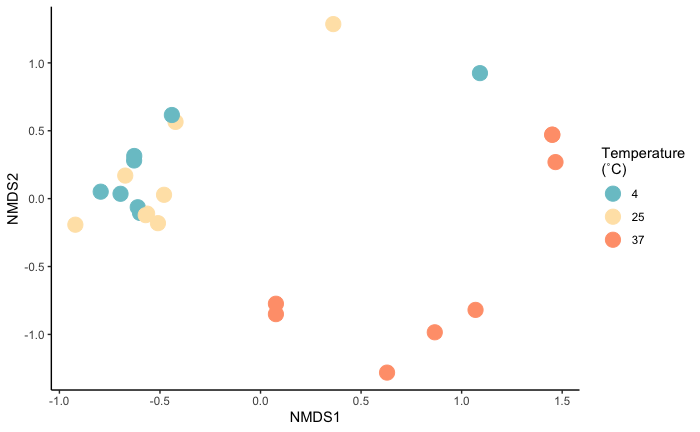

```r
#variables
gb_datascores = as.data.frame(vegan::scores(gb_nmds_2dim))
gb_datascores$GC = rownames(gb_datascores)
gb_datascores$medium = str_split_fixed(gb_datascores$GC, "_", 3)[,1]
gb_datascores$salt = str_split_fixed(gb_datascores$GC, "_", 3)[,2]
gb_datascores$temperature = str_split_fixed(gb_datascores$GC, "_", 3)[,3]
gb_datascores$salt = factor(gb_datascores$salt, levels = c("0", "2.5", "5", "10"))
gb_datascores$temperature = factor(gb_datascores$temperature, levels = c("4", "25", "37"))
(gb_NMDS12_temp = ggplot(data = gb_datascores, aes(x = NMDS1, y = NMDS2)) +
    geom_point(data = gb_datascores, aes(color = temperature), size = 5) +
    scale_color_manual(name = 'Temperature\n(˚C)', values = c("cadetblue3","moccasin", "lightsalmon")) +
    theme_classic())
```

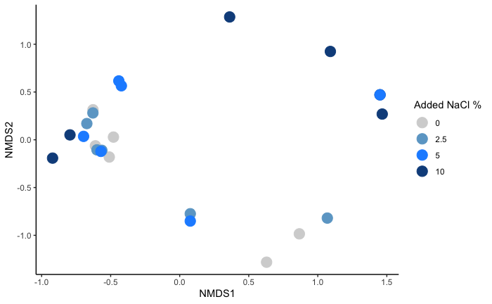

```r
(gb_NMDS12_salt = ggplot(data = gb_datascores, aes(x = NMDS1, y = NMDS2)) +
    geom_point(data = gb_datascores, aes(color = salt), size = 5) +
    scale_color_manual(name = 'Added NaCl %', values = c("grey83", "skyblue3", "dodgerblue", "dodgerblue4")) +
    theme_classic())
```

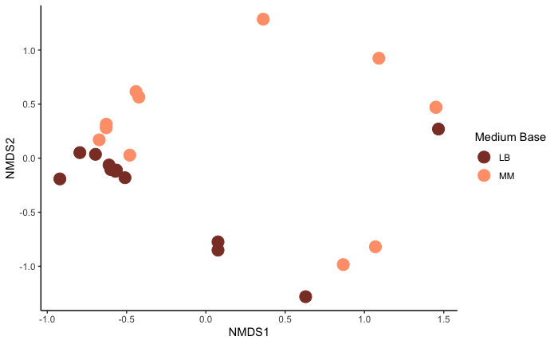

```r
(gb_NMDS12_med = ggplot(data = gb_datascores, aes(x = NMDS1, y = NMDS2)) +
    geom_point(data = gb_datascores, aes(color = medium), size = 5) +
    scale_color_manual(name = "Medium Base", values = c("coral4","lightsalmon")) +
    theme_classic())
```

```r
gb_en_var = envfit(gb_nmds_2dim, gb_datascores[,4:6], permutations = 1000)
gb_en_var
```

```
***FACTORS:

Centroids:
                NMDS1   NMDS2
mediumLB      -0.2515 -0.2769
mediumMM       0.2515  0.2769
salt0         -0.1221 -0.3612
salt2.5       -0.2198 -0.2264
salt5         -0.1005  0.1193
salt10         0.4425  0.4683
temperature4  -0.4134  0.2568
temperature25 -0.4724  0.1806
temperature37  0.8857 -0.4373

Goodness of fit:
                r2   Pr(>r)
medium      0.1394 0.045954 *
salt        0.1705 0.251748
temperature 0.4879 0.001998 **
---
Signif. codes:  0 ‘***’ 0.001 ‘**’ 0.01 ‘*’ 0.05 ‘.’ 0.1 ‘ ’ 1
Permutation: free
Number of permutations: 1000
```

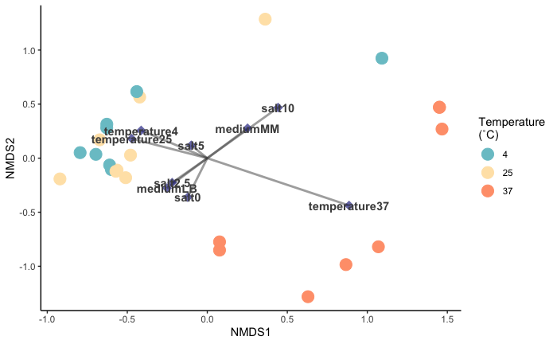

```r
gb_en_coord_fact = as.data.frame(vegan::scores(gb_en_var, "factors"))
(gb_NMDS12_temp_env = ggplot(data = gb_datascores, aes(x = NMDS1, y = NMDS2)) +
    geom_point(data = gb_datascores, aes(color = temperature), size = 5) +
    scale_color_manual(name = 'Temperature\n(˚C)', values = c("cadetblue3","moccasin", "lightsalmon")) +
    geom_segment(aes(x = 0, y = 0, xend = NMDS1, yend = NMDS2), data = gb_en_coord_fact, size = 1, alpha = 0.5, color = "grey30") +
    geom_point(data = gb_en_coord_fact, aes(x = NMDS1, y = NMDS2), shape = "diamond", size = 4, alpha = 0.6, color = "navy") +
    geom_text(data = gb_en_coord_fact, aes(x = NMDS1, y = NMDS2), colour = "grey30", fontface = "bold", label = row.names(gb_en_coord_fact)) +
    theme_classic())
```

[output not shown]

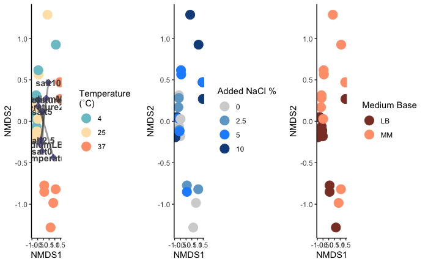

```r
ggarrange(gb_NMDS12_temp_env, gb_NMDS12_salt, gb_NMDS12_med, ncol = 3, align = 'hv')
```

```r
#now for the statistics
anosim(gb_for_nmds, grouping = gb_datascores$medium, distance = "bray", permutations = 9999)
```

```
Call:
anosim(x = gb_for_nmds, grouping = gb_datascores$medium, permutations = 9999,      distance = "bray")
Dissimilarity: bray

ANOSIM statistic R: 0.1466
      Significance: 0.0244

Permutation: free
Number of permutations: 9999
```

```r
anosim(gb_for_nmds, grouping = gb_datascores$salt, distance = "bray", permutations = 9999)
```

```
Call:
anosim(x = gb_for_nmds, grouping = gb_datascores$salt, permutations = 9999,      distance = "bray")
Dissimilarity: bray

ANOSIM statistic R: 0.1059
      Significance: 0.0786

Permutation: free
Number of permutations: 9999
```

```r
anosim(gb_for_nmds, grouping = gb_datascores$temperature, distance = "bray", permutations = 9999)
```

```
Call:
anosim(x = gb_for_nmds, grouping = gb_datascores$temperature,      permutations = 9999, distance = "bray")
Dissimilarity: bray

ANOSIM statistic R: 0.417
      Significance: 1e-04

Permutation: free
Number of permutations: 9999
```

### Figure 4.6

```r
gb_indscores = as.data.frame(vegan::scores(gb_nmds_2dim, "species"))
gb_indscores$strainID = rownames(gb_indscores)
gb_indscores = left_join(gb_indscores, psych_strain_collection[,c(3, 25:27)])
gb_en_ind = envfit(gb_indscores[,1:2], gb_indscores[,4:6], permutations = 1000, na.rm = TRUE)
gb_en_ind
```

```
***VECTORS

               NMDS1    NMDS2     r2   Pr(>r)
Latitude_j   0.45680 -0.88957 0.0488 0.178821
Longitude_j -0.51832  0.85519 0.1460 0.006993 **
---
Signif. codes:  0 ‘***’ 0.001 ‘**’ 0.01 ‘*’ 0.05 ‘.’ 0.1 ‘ ’ 1
Permutation: free
Number of permutations: 1000

***FACTORS:

Centroids:
                         NMDS1   NMDS2
ISME_sourcewarm host   -0.0350 -0.6479
ISME_sourceother host  -0.6709  0.0571
ISME_sourcefood        -0.6522  0.0998
ISME_sourcemarine      -0.5603 -0.0493
ISME_sourceterrestrial -0.6367  0.1097

Goodness of fit:
                r2   Pr(>r)
ISME_source 0.4634 0.000999 ***
---
Signif. codes:  0 ‘***’ 0.001 ‘**’ 0.01 ‘*’ 0.05 ‘.’ 0.1 ‘ ’ 1
Permutation: free
Number of permutations: 1000

16 observations deleted due to missingness
```

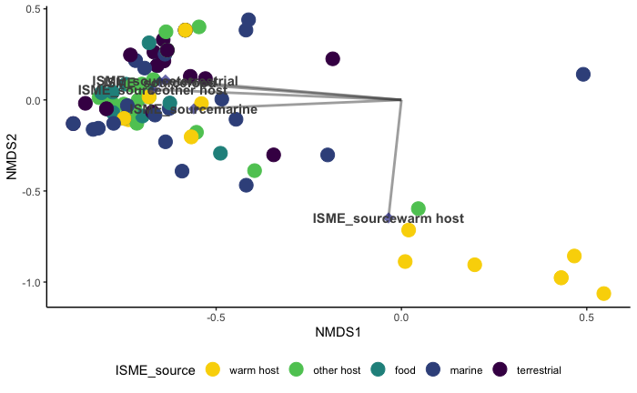

```r
gb_en_ind_coord_fact = as.data.frame(vegan::scores(gb_en_ind, "factors"))
(gb_NMDS12_ind = ggplot(data = gb_indscores, aes(x = NMDS1, y = NMDS2)) +
    geom_point(data = gb_indscores, aes(color = ISME_source), size = 5) +
    scale_color_manual(values = ISMEcolors) +
    geom_segment(aes(x = 0, y = 0, xend = NMDS1, yend = NMDS2), data = gb_en_ind_coord_fact, size = 1, alpha = 0.5, color = "grey30") +
    geom_point(data = gb_en_ind_coord_fact, aes(x = NMDS1, y = NMDS2), shape = "diamond", size = 4, alpha = 0.6, color = "navy") +
    geom_text(data = gb_en_ind_coord_fact, aes(x = NMDS1, y = NMDS2), colour = "grey30", fontface = "bold", label = row.names(gb_en_ind_coord_fact)) +
    theme_classic() +
    theme(legend.position = 'bottom'))
```

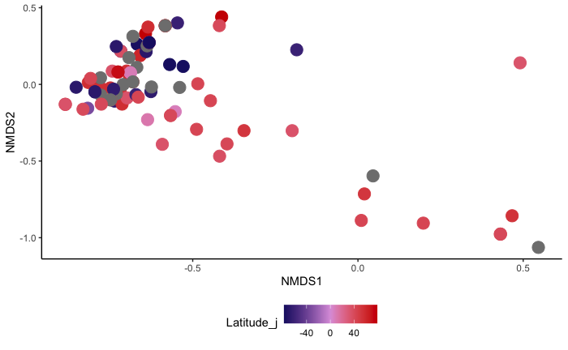

```r
(gb_NMDS12_ind_lat = ggplot(data = gb_indscores, aes(x = NMDS1, y = NMDS2)) +
    geom_point(data = gb_indscores, aes(color = Latitude_j), size = 5) +
    scale_color_gradient2(low = "midnightblue", mid = "plum", high = "red3") +
    theme_classic() +
    theme(legend.position = 'bottom'))
```

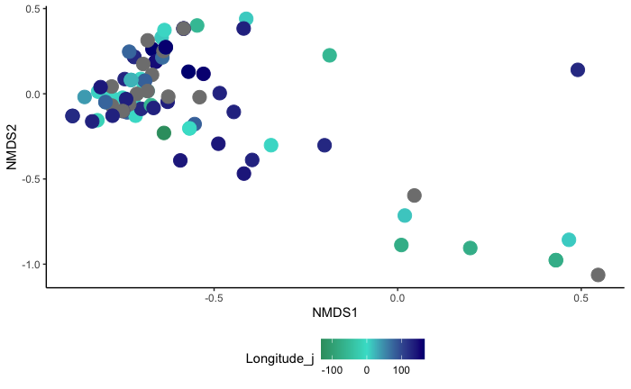

```r
(gb_NMDS12_ind_long = ggplot(data = gb_indscores, aes(x = NMDS1, y = NMDS2)) +
    geom_point(data = gb_indscores, aes(color = Longitude_j), size = 5) +
    scale_color_gradient2(low = "seagreen4", mid = "turquoise", high = "navyblue") +
    theme_classic() +
    theme(legend.position = 'bottom'))
```

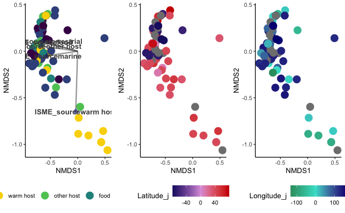

```r
ggarrange(gb_NMDS12_ind, gb_NMDS12_ind_lat, gb_NMDS12_ind_long, ncol = 3, align = 'hv')
```

```r
#for the stats
anosim(t(gb_for_nmds), grouping = gb_indscores$ISME_source, distance = "bray", permutations = 9999)
```

```
Call:
anosim(x = t(gb_for_nmds), grouping = gb_indscores$ISME_source,      permutations = 9999, distance = "bray")
Dissimilarity: bray

ANOSIM statistic R: 0.1211
      Significance: 3e-04

Permutation: free
Number of permutations: 9999
```

```r
gb_indscores_na_omit = na.omit(gb_indscores)
gb_for_nmds_t = t(gb_for_nmds)
gb_naomit = gb_for_nmds_t[rownames(gb_for_nmds_t) %in% gb_indscores_na_omit$strainID,]
anosim(gb_naomit, grouping = gb_indscores_na_omit$Latitude_j, distance = "bray", permutations = 9999)
```

```
Call:
anosim(x = gb_naomit, grouping = gb_indscores_na_omit$Latitude_j,      permutations = 9999, distance = "bray")
Dissimilarity: bray

ANOSIM statistic R: 0.2344
      Significance: 0.0163

Permutation: free
Number of permutations: 9999
```

```r
anosim(gb_naomit, grouping = gb_indscores_na_omit$Longitude_j, distance = "bray", permutations = 9999)
```

```
Call:
anosim(x = gb_naomit, grouping = gb_indscores_na_omit$Longitude_j,      permutations = 9999, distance = "bray")
Dissimilarity: bray

ANOSIM statistic R: 0.242
      Significance: 0.0353

Permutation: free
Number of permutations: 9999
```

### Figure 4.7

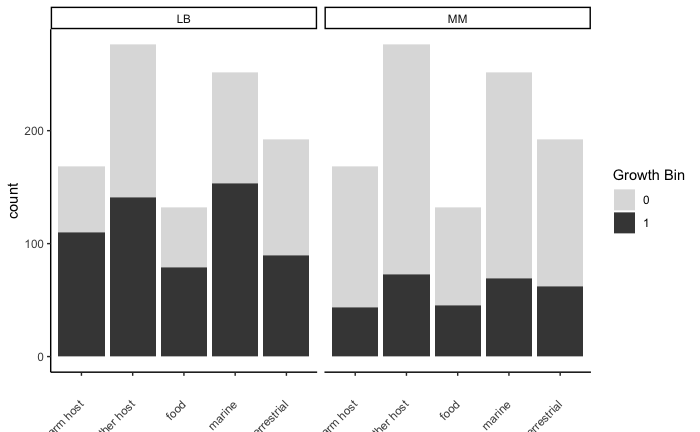

```r
colnames(psych_gb_distrib) = c("strainID", "GC", "value")
psych_gb_distrib$value[psych_gb_distrib$value <= 0.5] <- 0
psych_gb_distrib$value[psych_gb_distrib$value > 0.5] <- 1
psych_gb_distrib$medium = str_split_fixed(psych_gb_distrib$GC, "_", 3)[,1]
psych_gb_distrib$salt = str_split_fixed(psych_gb_distrib$GC, "_", 3)[,2]
psych_gb_distrib$temperature = str_split_fixed(psych_gb_distrib$GC, "_", 3)[,3]
psych_gb_distrib = left_join(psych_gb_distrib, psych_strain_collection[,c(3, 25:27)])
#iso source effect on gb in LB
(gb_med = ggplot() +
  geom_bar(data = psych_gb_distrib,
             aes(x = ISME_source, fill = as.factor(value)), stat = 'count') +
  scale_fill_manual(values = c("gray87", "gray27")) +
  facet_wrap(~medium) +
    theme_classic() +
    theme(axis.text.x = element_text(angle = 45, vjust = 0.5, hjust=1)) +
    theme(axis.title.x = element_blank()) +
    labs(fill = "Growth Bin"))
```

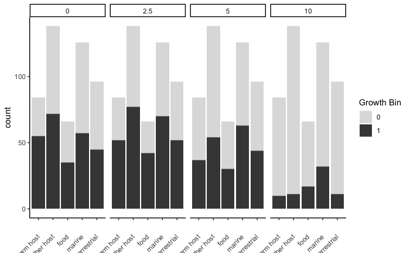

```r
psych_gb_distrib$salt = factor(psych_gb_distrib$salt, levels = c("0", "2.5", "5", "10"))
(gb_salt = ggplot() +
  geom_bar(data = psych_gb_distrib,
             aes(x = ISME_source, fill = as.factor(value)), stat = 'count') +
  scale_fill_manual(values = c("gray87", "gray27")) +
  facet_wrap(~salt, ncol = 4) +
    theme_classic() +
    theme(axis.text.x = element_text(angle = 45, vjust = 0.5, hjust=1)) +
    theme(axis.title.x = element_blank()) +
    labs(fill = "Growth Bin"))
```

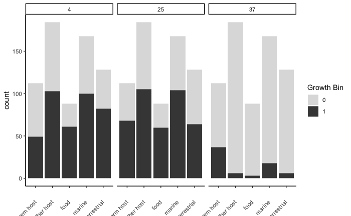

```r
psych_gb_distrib$temperature = factor(psych_gb_distrib$temperature, levels = c("4", "25", "37"))
(gb_temp = ggplot() +
  geom_bar(data = psych_gb_distrib,
             aes(x = ISME_source, fill = as.factor(value)), stat = 'count') +
  scale_fill_manual(values = c("gray87", "gray27")) +
  facet_wrap(~temperature, ncol = 3) +
    theme_classic() +
    theme(axis.text.x = element_text(angle = 45, vjust = 0.5, hjust=1)) +
    theme(axis.title.x = element_blank()) +
    labs(fill = "Growth Bin"))
```

```
Graphs cannot be vertically aligned unless the axis parameter is set. Placing graphs unaligned.
```

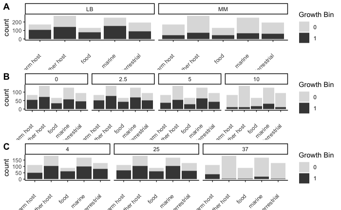

```r
ggarrange(gb_med, gb_salt, gb_temp, nrow = 3, align = 'v', labels = c("A", "B", "C"))
```

```r
gb_lb_test = psych_gb_distrib %>% filter(medium == "LB")
gb_lb_chi = chisq.test(x = gb_lb_test$ISME_source, y = gb_lb_test$value)
gb_0salt_test = psych_gb_distrib %>% filter(salt == "0")
gb_0salt_chi = chisq.test(x = gb_0salt_test$ISME_source, y = gb_0salt_test$value)
gb_4temp_test = psych_gb_distrib %>% filter(temperature == "4")
gb_4temp_chi = chisq.test(x = gb_4temp_test$ISME_source, y = gb_4temp_test$value)
gb_37temp_test = psych_gb_distrib %>% filter(temperature == "37")
gb_37temp_chi = chisq.test(x = gb_37temp_test$ISME_source, y = gb_37temp_test$value)
wh_pvals = c(gb_lb_chi$p.value, gb_0salt_chi$p.value, gb_4temp_chi$p.value, gb_37temp_chi$p.value)
wh_pval_padj = p.adjust(wh_pvals, method = "BH")
```

### Figure 4.8

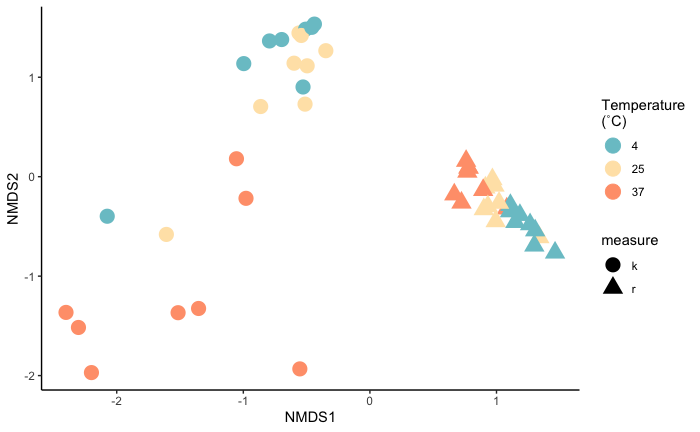

```r
#variables
kr_datascores = as.data.frame(vegan::scores(kr_nmds_2dim))
kr_datascores$gmeasure = rownames(kr_datascores)
kr_datascores$measure = str_split_fixed(kr_datascores$gmeasure, "_", 4)[,4]
kr_datascores$gc = str_remove(kr_datascores$gmeasure, "_r")
kr_datascores$gc = str_remove(kr_datascores$gc, "_k")
growthcurvedummy = unique(psychkr[,c(2:4,12)])
kr_datascores = left_join(kr_datascores, growthcurvedummy)
kr_datascores = kr_datascores %>% mutate_at(vars(salt, temperature), as.factor)
(kr_NMDS12_var_temp = ggplot(data = kr_datascores, aes(x = NMDS1, y = NMDS2)) +
    geom_point(data = kr_datascores, aes(color = temperature, shape = measure), size = 5) +
    scale_color_manual(name = 'Temperature\n(˚C)', values = c("cadetblue3","moccasin", "lightsalmon")) +
    theme_classic())
```

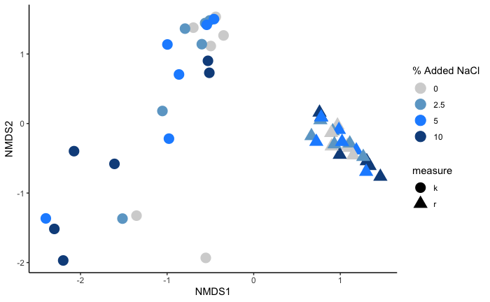

```r
(kr_NMDS12_var_salt = ggplot(data = kr_datascores, aes(x = NMDS1, y = NMDS2)) +
    geom_point(data = kr_datascores, aes(color = salt, shape = measure), size = 5) +
    scale_color_manual(name = '% Added NaCl', values = c("grey83", "skyblue3", "dodgerblue", "dodgerblue4")) +
    theme_classic())
```

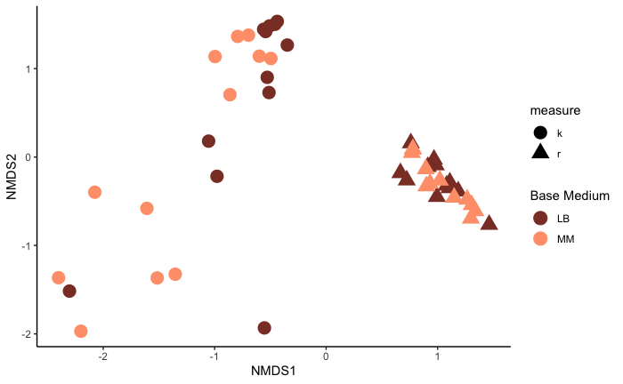

```r
(kr_NMDS12_var_med = ggplot(data = kr_datascores, aes(x = NMDS1, y = NMDS2)) +
    geom_point(data = kr_datascores, aes(color = medium, shape = measure), size = 5) +
    scale_color_manual(name = 'Base Medium', values = c("coral4","lightsalmon")) +
    theme_classic())
```

```r
kr_en_var = envfit(kr_nmds_2dim, kr_datascores[,c(4,6:8)], permutations = 1000)
kr_en_var
```

```
***FACTORS:

Centroids:
                NMDS1   NMDS2
measurek      -1.0159  0.2764
measurer       1.0159 -0.2764
mediumLB       0.1319  0.1556
mediumMM      -0.1319 -0.1556
salt0          0.1843  0.0352
salt2.5        0.0521  0.2454
salt5         -0.0208  0.1314
salt10        -0.2156 -0.4120
temperature4   0.2116  0.3094
temperature25  0.1574  0.3168
temperature37 -0.3691 -0.6262

Goodness of fit:
                r2   Pr(>r)
measure     0.5229 0.000999 ***
medium      0.0196 0.385614
salt        0.0392 0.750250
temperature 0.1248 0.018981 *
---
Signif. codes:  0 ‘***’ 0.001 ‘**’ 0.01 ‘*’ 0.05 ‘.’ 0.1 ‘ ’ 1
Permutation: free
Number of permutations: 1000
```

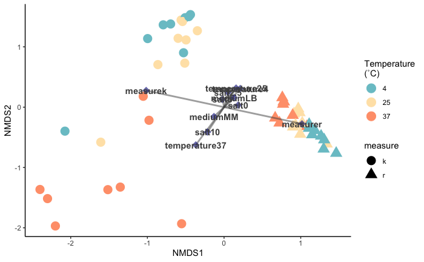

```r
kr_en_coord_fact = as.data.frame(vegan::scores(kr_en_var, "factors"))
(kr_NMDS12_var_temp_env = ggplot(data = kr_datascores, aes(x = NMDS1, y = NMDS2)) +
    geom_point(data = kr_datascores, aes(color = temperature, shape = measure), size = 5) +
    scale_color_manual(name = 'Temperature\n(˚C)', values = c("cadetblue3","moccasin", "lightsalmon")) +
    geom_segment(aes(x = 0, y = 0, xend = NMDS1, yend = NMDS2), data = kr_en_coord_fact, size = 1, alpha = 0.5, color = "grey30") +
    geom_point(data = kr_en_coord_fact, aes(x = NMDS1, y = NMDS2), shape = "diamond", size = 4, alpha = 0.6, color = "navy") +
    geom_text(data = kr_en_coord_fact, aes(x = NMDS1, y = NMDS2), colour = "grey30", fontface = "bold", label = row.names(kr_en_coord_fact)) +
    theme_classic())
```

[output not shown]

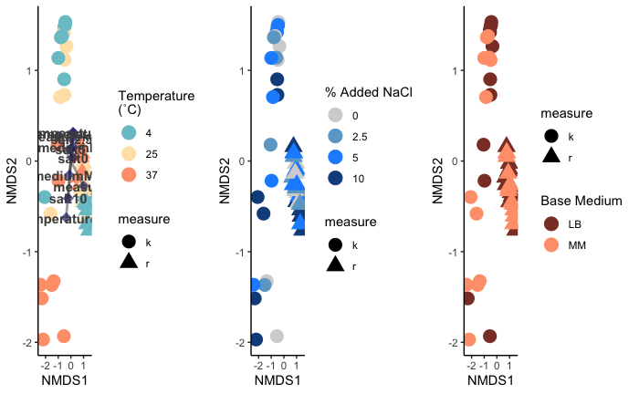

```r
ggarrange(kr_NMDS12_var_temp_env, kr_NMDS12_var_salt, kr_NMDS12_var_med, ncol = 3, align = 'hv')
```

```r
anosim(psych_kr_kr_t, grouping = kr_datascores$medium, distance = "bray", permutations = 9999)
```

```
Call:
anosim(x = psych_kr_kr_t, grouping = kr_datascores$medium, permutations = 9999,      distance = "bray")
Dissimilarity: bray

ANOSIM statistic R: 0.03911
      Significance: 0.085

Permutation: free
Number of permutations: 9999
```

```r
anosim(psych_kr_kr_t, grouping = kr_datascores$salt, distance = "bray", permutations = 9999)
```

```
Call:
anosim(x = psych_kr_kr_t, grouping = kr_datascores$salt, permutations = 9999,      distance = "bray")
Dissimilarity: bray

ANOSIM statistic R: -0.01612
      Significance: 0.6591

Permutation: free
Number of permutations: 9999
```

```r
anosim(psych_kr_kr_t, grouping = kr_datascores$temperature, distance = "bray", permutations = 9999)
```

```
Call:
anosim(x = psych_kr_kr_t, grouping = kr_datascores$temperature,      permutations = 9999, distance = "bray")
Dissimilarity: bray

ANOSIM statistic R: 0.1064
      Significance: 0.0047

Permutation: free
Number of permutations: 9999
```

### Figure 4.9

```r
#individuals
kr_indscores = as.data.frame(vegan::scores(kr_nmds_2dim, "species"))
kr_indscores$strainID = rownames(kr_indscores)
kr_indscores = left_join(kr_indscores, psych_strain_collection[,c(3, 25:27)])
kr_en_ind = envfit(kr_indscores[,1:2], kr_indscores[,4:6], permutations = 1000, na.rm = TRUE)
kr_en_ind
```

```
***VECTORS

               NMDS1    NMDS2     r2   Pr(>r)
Latitude_j  -0.67916 -0.73399 0.0334 0.325674
Longitude_j -0.89782  0.44035 0.2335 0.000999 ***
---
Signif. codes:  0 ‘***’ 0.001 ‘**’ 0.01 ‘*’ 0.05 ‘.’ 0.1 ‘ ’ 1
Permutation: free
Number of permutations: 1000

***FACTORS:

Centroids:
                         NMDS1   NMDS2
ISME_sourcewarm host    0.5945 -0.2350
ISME_sourceother host  -0.4109  1.3142
ISME_sourcefood        -0.5242  1.1866
ISME_sourcemarine      -0.3906  1.0429
ISME_sourceterrestrial -0.3396  1.1350

Goodness of fit:
                r2   Pr(>r)
ISME_source 0.4478 0.000999 ***
---
Signif. codes:  0 ‘***’ 0.001 ‘**’ 0.01 ‘*’ 0.05 ‘.’ 0.1 ‘ ’ 1
Permutation: free
Number of permutations: 1000

16 observations deleted due to missingness
```

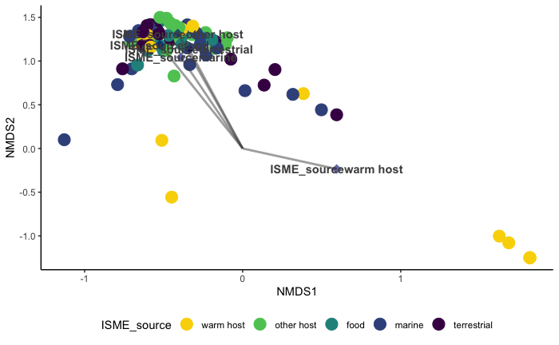

```r
kr_en_ind_coord_fact = as.data.frame(vegan::scores(kr_en_ind, "factors"))
(kr_NMDS12_ind = ggplot(data = kr_indscores, aes(x = NMDS1, y = NMDS2)) +
    geom_point(data = kr_indscores, aes(color = ISME_source), size = 5) +
    scale_color_manual(values = ISMEcolors) +
    geom_segment(aes(x = 0, y = 0, xend = NMDS1, yend = NMDS2), data = kr_en_ind_coord_fact, size = 1, alpha = 0.5, color = "grey30") +
    geom_point(data = kr_en_ind_coord_fact, aes(x = NMDS1, y = NMDS2), shape = "diamond", size = 4, alpha = 0.6, color = "navy") +
    geom_text(data = kr_en_ind_coord_fact, aes(x = NMDS1, y = NMDS2), colour = "grey30", fontface = "bold", label = row.names(kr_en_ind_coord_fact)) +
    theme_classic() +
    theme(legend.position = 'bottom'))
```

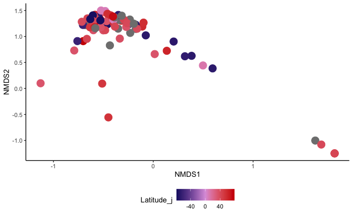

```r
(kr_NMDS12_ind_lat = ggplot(data = kr_indscores, aes(x = NMDS1, y = NMDS2)) +
    geom_point(data = kr_indscores, aes(color = Latitude_j), size = 5) +
    scale_color_gradient2(low = "midnightblue", mid = "plum", high = "red3") +
    theme_classic() +
    theme(legend.position = 'bottom'))
```

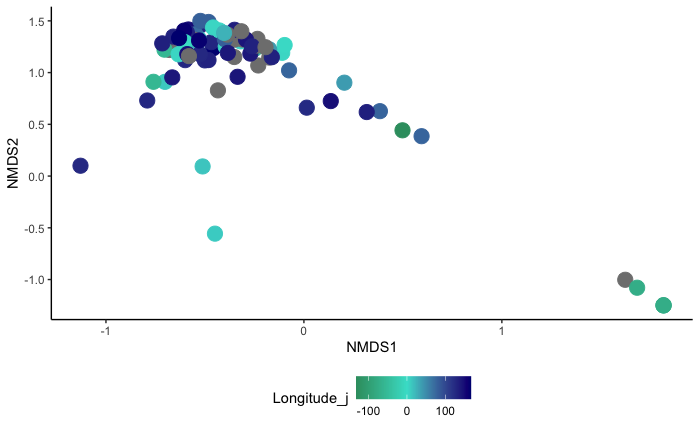

```r
(kr_NMDS12_ind_long = ggplot(data = kr_indscores, aes(x = NMDS1, y = NMDS2)) +
    geom_point(data = kr_indscores, aes(color = Longitude_j), size = 5) +
    scale_color_gradient2(low = "seagreen4", mid = "turquoise", high = "navyblue") +
    theme_classic() +
    theme(legend.position = 'bottom'))
```

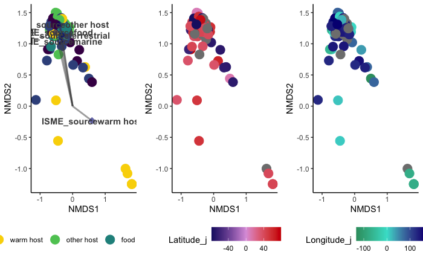

```r
ggarrange(kr_NMDS12_ind, kr_NMDS12_ind_lat, kr_NMDS12_ind_long, ncol = 3, align = 'hv')
```

```r
#the statistics
anosim(psych_kr_kr, grouping = kr_indscores$ISME_source, distance = "bray", permutations = 9999)
```

```
Call:
anosim(x = psych_kr_kr, grouping = kr_indscores$ISME_source,      permutations = 9999, distance = "bray")
Dissimilarity: bray

ANOSIM statistic R: 0.1133
      Significance: 3e-04

Permutation: free
Number of permutations: 9999
```

```r
#anosim(psych_kr_kr, grouping = kr_indscores$ecotype, distance = "bray", permutations = 9999)
kr_indscores_na_omit = na.omit(kr_indscores)
kr_naomit = psych_kr_kr[rownames(psych_kr_kr) %in% kr_indscores_na_omit$strainID,]
anosim(kr_naomit, grouping = kr_indscores_na_omit$Latitude_j, distance = "bray", permutations = 9999)
```

```
Call:
anosim(x = kr_naomit, grouping = kr_indscores_na_omit$Latitude_j,      permutations = 9999, distance = "bray")
Dissimilarity: bray

ANOSIM statistic R: 0.1235
      Significance: 0.1166

Permutation: free
Number of permutations: 9999
```

```r
anosim(kr_naomit, grouping = kr_indscores_na_omit$Longitude_j, distance = "bray", permutations = 9999)
```

```
Call:
anosim(x = kr_naomit, grouping = kr_indscores_na_omit$Longitude_j,      permutations = 9999, distance = "bray")
Dissimilarity: bray

ANOSIM statistic R: 0.2085
      Significance: 0.058

Permutation: free
Number of permutations: 9999
```